# Introduction to Python

- Slides by [Ahmed Moustafa](https://github.com/ahmedmoustafa)
- Content modified from [Pierian Data](https://github.com/Pierian-Data/Complete-Python-3-Bootcamp)

# What is Python and why use it

- **high-level**,
- **interpreted**,
- **general-purpose** programming language that is used for a wide range of applications.
- It is **easy to learn**, and
- **powerful**.

# Why is it called Python?

When he began implementing Python, Guido van Rossum (left) was also reading the published scripts from “Monty Python's Flying Circus” (Right), a BBC comedy series from the 1970s. Van Rossum thought he needed a name that was short, unique, and slightly mysterious, so he decided to call the language Python. <sub>--General Python FAQ</sub>

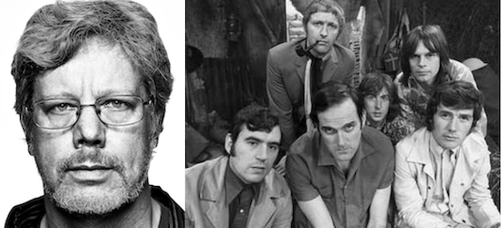

# Working with Python using Google Colab

Homepage: https://colab.research.google.com/ (runs online, cloud-computing like)

[figure not shown]

# Working with Python using JupyterLab Desktop

Homepage: https://github.com/jupyterlab/jupyterlab-desktop (runs offline, desktop)

[figure not shown]

# First Things First

As with any programming course, here is the `Hello World!` in Python.

```python
print ("Hello World!")
```

```
Hello World!
```

[figure not shown]

# Variable

A variable is a named storage location used to hold a value. The value of a variable can be changed and it can be used in expressions and operations

# Variable Assignment

- names can not start with a number
- names can not contain spaces, use _ intead
- names can not contain any of these symbols: `'",<>/?|\!@#%^&*~-+`
- accoding to Style Guide for Python Code ([PEP8](https://www.python.org/dev/peps/pep-0008/#function-and-variable-names)), it's considered best practice that names are lowercase with underscores
- avoid using Python built-in keywords like `list` and `str`
- avoid using the single characters `l` (lowercase letter el), `O` (uppercase letter oh) and `I` (uppercase letter eye) as they can be confused with 1 and 0

# Dynamic Typing

Python uses *dynamic typing*, meaning you can reassign variables to different data types. This makes Python very flexible in assigning data types; it differs from other languages that are statically typed.

```python
my_cat = 2
my_cat
```

```
2
```

```python
my_cat = ['Basbousa', 'Lucy']
my_cat
```

```
['Basbousa', 'Lucy']
```

# Pros and Cons of Dynamic Typing

- Pros of Dynamic Typing
  - very easy to work with
  - faster development time
- Cons of Dynamic Typing
  - may result in unexpected bugs!

# Assigning Variables

Variable assignment follows `name = object`, where a single equals sign `=` is an assignment operator

```python
a = 5
a
```

```
5
```

# Reassigning Variables

Python lets you reassign variables with a reference to the same object.

```python
a = a + 10
a
```

```
15
```

There's actually a shortcut for this. Python lets you add, subtract, multiply and divide numbers with reassignment using `+=`, `-=`, `*=`, and `/=`.

```python
a += 10
a
```

```
25
```

```python
a *= 2
a
```

```
50
```

# Determining variable type with `type()`

```python
type(a)
```

```
int
```

# Numbers

Basically there are two types of numbers:

- 2 is interger `int`
- 2.0 is floating point `float`

| Example | Number Type |
| --- | --- |
| 1,2,-5,1000 | Integers |
| 1.2,-0.5,2e2,3E2 | Floating point |

```python
type(2)
```

```
int
```

```python
type(2.0)
```

```
float
```

# Basic Arithmetic 1/2

```python
2+1 # Addition
```

```
3
```

```python
2-1 # Subtraction
```

```
1
```

```python
2*2 # Multiplication
```

```
4
```

```python
3/2 # Division
```

```
1.5
```

# Basic Arithmetic 2/2

```python
3//2 # Floor division (It returns the result of division rounded down to the nearest integer)
```

```
1
```

```python
2**3 # Powers
```

```
8
```

Question: how to calculate the sequare root of 16?

# Order of Operations

```python
2 + 10 * 10 + 3
```

```
105
```

```python
(2+10) * (10+3)
```

```
156
```

# Strings

Strings in Python are **text**, such as names, stored as a sequence or a list of characters. For example, Python understands the string `'AUC'` to be a sequence of letters in a specific order. This means we will be able to use indexing to grab particular letters (like the first letter `A`, or the last letter `C`).

# Creating a String

To create a string in Python you need to use either single quotes `'` or double quotes `"`.

```python
'Hello'
```

```
'Hello'
```

```python
'Hello World!'
```

```
'Hello World!'
```

```python
"This is also a string"
```

```
'This is also a string'
```

```python
'I'm using single quotes, but this will create an error'
```

```
  Cell In[27], line 1
    'I'm using single quotes, but this will create an error'
       ^
SyntaxError: invalid syntax
```

```python
'Now I\'m ready to use the single quotes inside a string!' # Using escape character
```

```
"Now I'm ready to use the single quotes inside a string!"
```

```python
"Now I'm ready to use the single quotes inside a string!" # Using double quotes
```

```
"Now I'm ready to use the single quotes inside a string!"
```

# Printing a String

Using Jupyter notebook with just a string in a cell will automatically output strings, but the correct way to display strings in your output is by using a `print` function.

```python
'Hello World'
```

```
'Hello World'
```

```python
'Hello World 1'
'Hello World 2'
```

```
'Hello World 2'
```

```python
print('Hello World 1')
print('Hello World 2')
```

```
Hello World 1
Hello World 2
```

```python
print('Hello World 1\nHello World 2') # using \n for new line
```

```
Hello World 1
Hello World 2
```

# String Indexing 1/3

Since strings are a sequence, we can use brackets `[]` after an object to call its index. We should also note that indexing **starts at 0** for Python.

```python
name = 'Emma'
name
```

```
'Emma'
```

```python
name[0]
```

```
'E'
```

```python
name[1]
```

```
'm'
```

```python
name[-1]
```

```
'a'
```

# String Indexing 2/3

```python
name[:2]
```

```
'Em'
```

```python
name[2:]
```

```
'ma'
```

```python
name[::1]
```

```
'Emma'
```

# String Indexing 3/3

```python
name[::2]
```

```
'Em'
```

What will be the ouptut of `name[::-1]`

# String Properties 1/3

String in Python are **immutable** i.e., once a string is created, the elements within it can not be changed or replaced.

```python
name
```

```
'Emma'
```

```python
name[0] = 'e'
```

```
---------------------------------------------------------------------------
TypeError                                 Traceback (most recent call last)
Cell In[43], line 1
----> 1 name[0] = 'e'

TypeError: 'str' object does not support item assignment
```

# String Properties 2/3

So if we need to change the value of a string, we will need to **reassign** it the new value:

```python
name = name + " Stone"
name
```

```
'Emma Stone'
```

[figure not shown]

# String Properties 3/3

```python
name * 5
```

```
'Emma StoneEmma StoneEmma StoneEmma StoneEmma Stone'
```

# Bulit-in String Method

In Python, we can call objects' methods with a period and then the method name in the following form: `object.method(parameters)`. And here are some built-in methods in strings:

```python
name.upper() # Convert to upper case
```

```
'EMMA STONE'
```

```python
name.lower() # Convert to lower case
```

```
'emma stone'
```

```python
name.split()  # Split by a separator (the default are white spaces)
```

```
['Emma', 'Stone']
```

```python
name.replace("m", "M")
```

```
'EMMa Stone'
```

# More Python String Methods

A comprehensive list of string methods in Python can be found:

- here: [Python String Functions at Digital Ocean](https://www.digitalocean.com/community/tutorials/python-string-functions), and
- here: [Python String Methods at Geeks for Geeks](https://www.geeksforgeeks.org/python-string-methods/)

BTW, both are excellent resources for additional documentation and examples.

# Summary

- Python is awesome
- Python uses **dynamic typing**
- Parentheses `( )` are for calling **functions**
- Square brackets `[ ]` are are indexing **lists**
- Strings are **immutable** lists
- Lists start indexing at **zero**

```python
print("Thank you!")
```

```
Thank you!
```

[figure not shown]